# Risk Factor Analysis

## Outcome Variable

**Outcome Variable:** haz

## Predictor Variables

**Intervention Variable:** hdlvry

**Adjustment Set:**

unadjusted

## Stratifying Variables

The analysis was stratified on these variable(s):

- agecat
- studyid
- country

## Data Summary

| agecat | studyid | country | hdlvry | n_cell | n |
| --- | --- | --- | --- | --- | --- |
| Birth | CMC-V-BCS-2002 | INDIA | 0 | 92 | 92 |
| Birth | CMC-V-BCS-2002 | INDIA | 1 | 0 | 92 |
| Birth | COHORTS | INDIA | 0 | 2938 | 4694 |
| Birth | COHORTS | INDIA | 1 | 1756 | 4694 |
| Birth | EE | PAKISTAN | 0 | 161 | 238 |
| Birth | EE | PAKISTAN | 1 | 77 | 238 |
| Birth | GMS-Nepal | NEPAL | 0 | 157 | 646 |
| Birth | GMS-Nepal | NEPAL | 1 | 489 | 646 |
| Birth | IRC | INDIA | 0 | 381 | 388 |
| Birth | IRC | INDIA | 1 | 7 | 388 |
| Birth | JiVitA-3 | BANGLADESH | 0 | 30 | 334 |
| Birth | JiVitA-3 | BANGLADESH | 1 | 304 | 334 |
| Birth | JiVitA-4 | BANGLADESH | 0 | 554 | 2808 |
| Birth | JiVitA-4 | BANGLADESH | 1 | 2254 | 2808 |
| Birth | NIH-Crypto | BANGLADESH | 0 | 567 | 732 |
| Birth | NIH-Crypto | BANGLADESH | 1 | 165 | 732 |
| Birth | PROVIDE | BANGLADESH | 0 | 391 | 539 |
| Birth | PROVIDE | BANGLADESH | 1 | 148 | 539 |
| Birth | SAS-CompFeed | INDIA | 0 | 124 | 1085 |
| Birth | SAS-CompFeed | INDIA | 1 | 961 | 1085 |
| 6 months | CMC-V-BCS-2002 | INDIA | 0 | 358 | 366 |
| 6 months | CMC-V-BCS-2002 | INDIA | 1 | 8 | 366 |
| 6 months | COHORTS | INDIA | 0 | 2900 | 4699 |
| 6 months | COHORTS | INDIA | 1 | 1799 | 4699 |
| 6 months | EE | PAKISTAN | 0 | 250 | 371 |
| 6 months | EE | PAKISTAN | 1 | 121 | 371 |
| 6 months | GMS-Nepal | NEPAL | 0 | 129 | 528 |
| 6 months | GMS-Nepal | NEPAL | 1 | 399 | 528 |
| 6 months | IRC | INDIA | 0 | 399 | 407 |
| 6 months | IRC | INDIA | 1 | 8 | 407 |
| 6 months | JiVitA-3 | BANGLADESH | 0 | 39 | 332 |
| 6 months | JiVitA-3 | BANGLADESH | 1 | 293 | 332 |
| 6 months | JiVitA-4 | BANGLADESH | 0 | 1081 | 4038 |
| 6 months | JiVitA-4 | BANGLADESH | 1 | 2957 | 4038 |
| 6 months | NIH-Crypto | BANGLADESH | 0 | 554 | 715 |
| 6 months | NIH-Crypto | BANGLADESH | 1 | 161 | 715 |
| 6 months | PROVIDE | BANGLADESH | 0 | 450 | 604 |
| 6 months | PROVIDE | BANGLADESH | 1 | 154 | 604 |
| 6 months | SAS-CompFeed | INDIA | 0 | 147 | 1091 |
| 6 months | SAS-CompFeed | INDIA | 1 | 944 | 1091 |
| 6 months | SAS-FoodSuppl | INDIA | 0 | 76 | 380 |
| 6 months | SAS-FoodSuppl | INDIA | 1 | 304 | 380 |
| 6 months | TanzaniaChild2 | TANZANIA, UNITED REPUBLIC OF | 0 | 1889 | 1921 |
| 6 months | TanzaniaChild2 | TANZANIA, UNITED REPUBLIC OF | 1 | 32 | 1921 |
| 24 months | CMC-V-BCS-2002 | INDIA | 0 | 360 | 368 |
| 24 months | CMC-V-BCS-2002 | INDIA | 1 | 8 | 368 |
| 24 months | COHORTS | INDIA | 0 | 2233 | 3556 |
| 24 months | COHORTS | INDIA | 1 | 1323 | 3556 |
| 24 months | EE | PAKISTAN | 0 | 112 | 166 |
| 24 months | EE | PAKISTAN | 1 | 54 | 166 |
| 24 months | GMS-Nepal | NEPAL | 0 | 118 | 456 |
| 24 months | GMS-Nepal | NEPAL | 1 | 338 | 456 |
| 24 months | IRC | INDIA | 0 | 401 | 409 |
| 24 months | IRC | INDIA | 1 | 8 | 409 |
| 24 months | JiVitA-3 | BANGLADESH | 0 | 35 | 291 |
| 24 months | JiVitA-3 | BANGLADESH | 1 | 256 | 291 |
| 24 months | JiVitA-4 | BANGLADESH | 0 | 1033 | 4005 |
| 24 months | JiVitA-4 | BANGLADESH | 1 | 2972 | 4005 |
| 24 months | NIH-Crypto | BANGLADESH | 0 | 391 | 514 |
| 24 months | NIH-Crypto | BANGLADESH | 1 | 123 | 514 |
| 24 months | PROVIDE | BANGLADESH | 0 | 433 | 578 |
| 24 months | PROVIDE | BANGLADESH | 1 | 145 | 578 |
| 24 months | TanzaniaChild2 | TANZANIA, UNITED REPUBLIC OF | 0 | 6 | 6 |
| 24 months | TanzaniaChild2 | TANZANIA, UNITED REPUBLIC OF | 1 | 0 | 6 |

The following strata were considered:

- agecat: 24 months, studyid: CMC-V-BCS-2002, country: INDIA
- agecat: 24 months, studyid: COHORTS, country: INDIA
- agecat: 24 months, studyid: EE, country: PAKISTAN
- agecat: 24 months, studyid: GMS-Nepal, country: NEPAL
- agecat: 24 months, studyid: IRC, country: INDIA
- agecat: 24 months, studyid: JiVitA-3, country: BANGLADESH
- agecat: 24 months, studyid: JiVitA-4, country: BANGLADESH
- agecat: 24 months, studyid: NIH-Crypto, country: BANGLADESH
- agecat: 24 months, studyid: PROVIDE, country: BANGLADESH
- agecat: 24 months, studyid: TanzaniaChild2, country: TANZANIA, UNITED REPUBLIC OF
- agecat: 6 months, studyid: CMC-V-BCS-2002, country: INDIA
- agecat: 6 months, studyid: COHORTS, country: INDIA
- agecat: 6 months, studyid: EE, country: PAKISTAN
- agecat: 6 months, studyid: GMS-Nepal, country: NEPAL
- agecat: 6 months, studyid: IRC, country: INDIA
- agecat: 6 months, studyid: JiVitA-3, country: BANGLADESH
- agecat: 6 months, studyid: JiVitA-4, country: BANGLADESH
- agecat: 6 months, studyid: NIH-Crypto, country: BANGLADESH
- agecat: 6 months, studyid: PROVIDE, country: BANGLADESH
- agecat: 6 months, studyid: SAS-CompFeed, country: INDIA
- agecat: 6 months, studyid: SAS-FoodSuppl, country: INDIA
- agecat: 6 months, studyid: TanzaniaChild2, country: TANZANIA, UNITED REPUBLIC OF
- agecat: Birth, studyid: CMC-V-BCS-2002, country: INDIA
- agecat: Birth, studyid: COHORTS, country: INDIA
- agecat: Birth, studyid: EE, country: PAKISTAN
- agecat: Birth, studyid: GMS-Nepal, country: NEPAL
- agecat: Birth, studyid: IRC, country: INDIA
- agecat: Birth, studyid: JiVitA-3, country: BANGLADESH
- agecat: Birth, studyid: JiVitA-4, country: BANGLADESH
- agecat: Birth, studyid: NIH-Crypto, country: BANGLADESH
- agecat: Birth, studyid: PROVIDE, country: BANGLADESH
- agecat: Birth, studyid: SAS-CompFeed, country: INDIA

### Dropped Strata

Some strata were dropped due to rare outcomes:

- agecat: Birth, studyid: CMC-V-BCS-2002, country: INDIA
- agecat: 24 months, studyid: TanzaniaChild2, country: TANZANIA, UNITED REPUBLIC OF

## Methods Detail

We’re interested in the causal parameters $E[Y_a]$ for all values of $a \in \mathcal{A}$. These parameters represent the mean outcome if, possibly contrary to fact, we intervened to set all units to have $A=a$. Under the randomization and positivity assumptions, these are identified by the statistical parameters $\psi_a=E_W[E_{Y|A,W}(Y|A=a,W)]$. In addition, we’re interested in the mean of $Y$, $E[Y]$ under no intervention (the observed mean). We will estimate these parameters by using SuperLearner to fit the relevant likelihood factors – $E_{Y|A,W}(Y|A=a,W)$ and $p(A=a|W)$, and then updating our likelihood fit using a joint TMLE.

For unadjusted analyses ($W=\{\}$), initial likelihoods were estimated using Lrnr_glm to estimate the simple $E(Y|A)$ and Lrnr_mean to estimate $p(A)$. For adjusted analyses, a small library containing Lrnr_glmnet, Lrnr_xgboost, and Lrnr_mean was used.

Having estimated these parameters, we will then use the delta method to estimate relative risks and attributable risks relative to a prespecified baseline level of $A$.

# Results Detail

## Results Plots

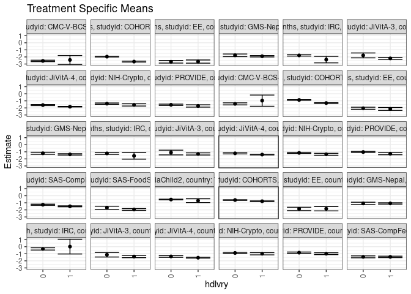

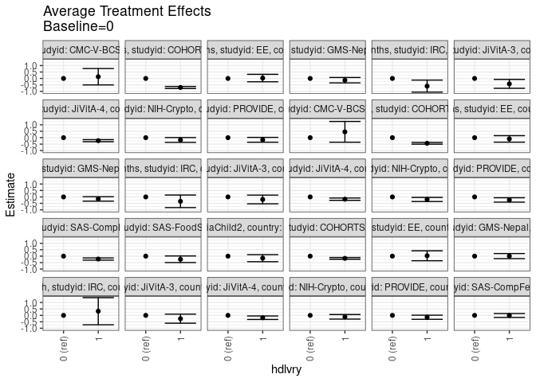

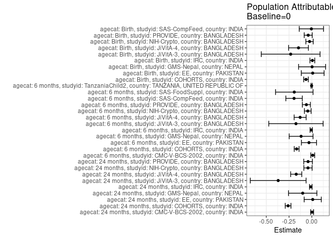

## Results Table

### Parameter: TSM

| agecat | studyid | country | intervention_level | baseline_level | estimate | ci_lower | ci_upper |
| --- | --- | --- | --- | --- | --- | --- | --- |
| Birth | COHORTS | INDIA | 0 | NA | -0.6120967 | -0.6545560 | -0.5696373 |
| Birth | COHORTS | INDIA | 1 | NA | -0.7835649 | -0.8357866 | -0.7313433 |
| Birth | EE | PAKISTAN | 0 | NA | -1.8709317 | -2.1088523 | -1.6330111 |
| Birth | EE | PAKISTAN | 1 | NA | -1.8415584 | -2.1459255 | -1.5371913 |
| Birth | GMS-Nepal | NEPAL | 0 | NA | -1.0936943 | -1.2658679 | -0.9215207 |
| Birth | GMS-Nepal | NEPAL | 1 | NA | -1.0900613 | -1.1839811 | -0.9961416 |
| Birth | IRC | INDIA | 0 | NA | -0.3138845 | -0.4765233 | -0.1512457 |
| Birth | IRC | INDIA | 1 | NA | 0.0100000 | -1.0310607 | 1.0510607 |
| Birth | JiVitA-3 | BANGLADESH | 0 | NA | -1.1360000 | -1.4582039 | -0.8137961 |
| Birth | JiVitA-3 | BANGLADESH | 1 | NA | -1.3914145 | -1.5544894 | -1.2283396 |
| Birth | JiVitA-4 | BANGLADESH | 0 | NA | -1.3752347 | -1.4986333 | -1.2518360 |
| Birth | JiVitA-4 | BANGLADESH | 1 | NA | -1.5576309 | -1.6122446 | -1.5030172 |
| Birth | NIH-Crypto | BANGLADESH | 0 | NA | -0.8844797 | -0.9640283 | -0.8049312 |
| Birth | NIH-Crypto | BANGLADESH | 1 | NA | -0.9954545 | -1.1551642 | -0.8357449 |
| Birth | PROVIDE | BANGLADESH | 0 | NA | -0.8453197 | -0.9356104 | -0.7550290 |
| Birth | PROVIDE | BANGLADESH | 1 | NA | -0.9902027 | -1.1220055 | -0.8583999 |
| Birth | SAS-CompFeed | INDIA | 0 | NA | -1.4350806 | -1.5710316 | -1.2991297 |
| Birth | SAS-CompFeed | INDIA | 1 | NA | -1.4408429 | -1.5411051 | -1.3405807 |
| 6 months | CMC-V-BCS-2002 | INDIA | 0 | NA | -1.4288687 | -1.5726614 | -1.2850760 |
| 6 months | CMC-V-BCS-2002 | INDIA | 1 | NA | -0.9754167 | -1.7693720 | -0.1814613 |
| 6 months | COHORTS | INDIA | 0 | NA | -0.8786897 | -0.9206224 | -0.8367569 |
| 6 months | COHORTS | INDIA | 1 | NA | -1.3152029 | -1.3685317 | -1.2618741 |
| 6 months | EE | PAKISTAN | 0 | NA | -2.0512200 | -2.1980983 | -1.9043417 |
| 6 months | EE | PAKISTAN | 1 | NA | -2.1475758 | -2.3529895 | -1.9421620 |
| 6 months | GMS-Nepal | NEPAL | 0 | NA | -1.2116150 | -1.3567293 | -1.0665007 |
| 6 months | GMS-Nepal | NEPAL | 1 | NA | -1.3677820 | -1.4618996 | -1.2736643 |
| 6 months | IRC | INDIA | 0 | NA | -1.2276901 | -1.3618868 | -1.0934933 |
| 6 months | IRC | INDIA | 1 | NA | -1.5693750 | -2.0379505 | -1.1007995 |
| 6 months | JiVitA-3 | BANGLADESH | 0 | NA | -1.1043590 | -1.4380294 | -0.7706885 |
| 6 months | JiVitA-3 | BANGLADESH | 1 | NA | -1.3019454 | -1.4524263 | -1.1514645 |
| 6 months | JiVitA-4 | BANGLADESH | 0 | NA | -1.2194033 | -1.2993889 | -1.1394178 |
| 6 months | JiVitA-4 | BANGLADESH | 1 | NA | -1.3951894 | -1.4427840 | -1.3475948 |
| 6 months | NIH-Crypto | BANGLADESH | 0 | NA | -1.1538899 | -1.2366235 | -1.0711563 |
| 6 months | NIH-Crypto | BANGLADESH | 1 | NA | -1.3527950 | -1.4899409 | -1.2156492 |
| 6 months | PROVIDE | BANGLADESH | 0 | NA | -1.0317815 | -1.1173452 | -0.9462178 |
| 6 months | PROVIDE | BANGLADESH | 1 | NA | -1.2667532 | -1.4139568 | -1.1195497 |
| 6 months | SAS-CompFeed | INDIA | 0 | NA | -1.2747619 | -1.3533985 | -1.1961254 |
| 6 months | SAS-CompFeed | INDIA | 1 | NA | -1.5003549 | -1.5683575 | -1.4323523 |
| 6 months | SAS-FoodSuppl | INDIA | 0 | NA | -1.7059211 | -1.9277126 | -1.4841295 |
| 6 months | SAS-FoodSuppl | INDIA | 1 | NA | -1.9468750 | -2.0764992 | -1.8172508 |
| 6 months | TanzaniaChild2 | TANZANIA, UNITED REPUBLIC OF | 0 | NA | -0.5414554 | -0.5927823 | -0.4901284 |
| 6 months | TanzaniaChild2 | TANZANIA, UNITED REPUBLIC OF | 1 | NA | -0.6976563 | -0.9673928 | -0.4279197 |
| 24 months | CMC-V-BCS-2002 | INDIA | 0 | NA | -2.5640139 | -2.6645275 | -2.4635003 |
| 24 months | CMC-V-BCS-2002 | INDIA | 1 | NA | -2.4300000 | -3.0592261 | -1.8007739 |
| 24 months | COHORTS | INDIA | 0 | NA | -1.9611554 | -2.0100096 | -1.9123012 |
| 24 months | COHORTS | INDIA | 1 | NA | -2.6618141 | -2.7245275 | -2.5991006 |
| 24 months | EE | PAKISTAN | 0 | NA | -2.6867708 | -2.8710517 | -2.5024900 |
| 24 months | EE | PAKISTAN | 1 | NA | -2.6568519 | -2.8801576 | -2.4335461 |
| 24 months | GMS-Nepal | NEPAL | 0 | NA | -1.7715395 | -1.9569262 | -1.5861529 |
| 24 months | GMS-Nepal | NEPAL | 1 | NA | -1.9067998 | -2.0050549 | -1.8085447 |
| 24 months | IRC | INDIA | 0 | NA | -1.7871446 | -1.8820825 | -1.6922068 |
| 24 months | IRC | INDIA | 1 | NA | -2.3818750 | -2.8405973 | -1.9231527 |
| 24 months | JiVitA-3 | BANGLADESH | 0 | NA | -1.7877143 | -2.1337599 | -1.4416687 |
| 24 months | JiVitA-3 | BANGLADESH | 1 | NA | -2.2076953 | -2.3502870 | -2.0651036 |
| 24 months | JiVitA-4 | BANGLADESH | 0 | NA | -1.6009874 | -1.6738326 | -1.5281422 |
| 24 months | JiVitA-4 | BANGLADESH | 1 | NA | -1.8322376 | -1.8755896 | -1.7888855 |
| 24 months | NIH-Crypto | BANGLADESH | 0 | NA | -1.3988747 | -1.4962574 | -1.3014920 |
| 24 months | NIH-Crypto | BANGLADESH | 1 | NA | -1.5760163 | -1.7360738 | -1.4159587 |
| 24 months | PROVIDE | BANGLADESH | 0 | NA | -1.5611085 | -1.6579435 | -1.4642736 |
| 24 months | PROVIDE | BANGLADESH | 1 | NA | -1.7257931 | -1.8875102 | -1.5640760 |

### Parameter: E(Y)

| agecat | studyid | country | intervention_level | baseline_level | estimate | ci_lower | ci_upper |
| --- | --- | --- | --- | --- | --- | --- | --- |
| Birth | COHORTS | INDIA | NA | NA | -0.6762420 | -0.7093108 | -0.6431732 |
| Birth | EE | PAKISTAN | NA | NA | -1.8614286 | -2.0501173 | -1.6727398 |
| Birth | GMS-Nepal | NEPAL | NA | NA | -1.0909443 | -1.1734385 | -1.0084500 |
| Birth | IRC | INDIA | NA | NA | -0.3080412 | -0.4687931 | -0.1472894 |
| Birth | JiVitA-3 | BANGLADESH | NA | NA | -1.3684731 | -1.5219775 | -1.2149687 |
| Birth | JiVitA-4 | BANGLADESH | NA | NA | -1.5216453 | -1.5715117 | -1.4717789 |
| Birth | NIH-Crypto | BANGLADESH | NA | NA | -0.9094945 | -0.9809370 | -0.8380521 |
| Birth | PROVIDE | BANGLADESH | NA | NA | -0.8851020 | -0.9601332 | -0.8100709 |
| Birth | SAS-CompFeed | INDIA | NA | NA | -1.4401843 | -1.5334809 | -1.3468878 |
| 6 months | CMC-V-BCS-2002 | INDIA | NA | NA | -1.4189572 | -1.5607165 | -1.2771979 |
| 6 months | COHORTS | INDIA | NA | NA | -1.0458076 | -1.0793244 | -1.0122908 |
| 6 months | EE | PAKISTAN | NA | NA | -2.0826460 | -2.2022514 | -1.9630406 |
| 6 months | GMS-Nepal | NEPAL | NA | NA | -1.3296275 | -1.4093037 | -1.2499514 |
| 6 months | IRC | INDIA | NA | NA | -1.2344062 | -1.3658524 | -1.1029600 |
| 6 months | JiVitA-3 | BANGLADESH | NA | NA | -1.2787349 | -1.4248268 | -1.1326431 |
| 6 months | JiVitA-4 | BANGLADESH | NA | NA | -1.3481303 | -1.3904710 | -1.3057895 |
| 6 months | NIH-Crypto | BANGLADESH | NA | NA | -1.1986783 | -1.2700937 | -1.1272630 |
| 6 months | PROVIDE | BANGLADESH | NA | NA | -1.0916915 | -1.1661176 | -1.0172654 |
| 6 months | SAS-CompFeed | INDIA | NA | NA | -1.4699588 | -1.5446559 | -1.3952616 |
| 6 months | SAS-FoodSuppl | INDIA | NA | NA | -1.8986842 | -2.0118892 | -1.7854792 |
| 6 months | TanzaniaChild2 | TANZANIA, UNITED REPUBLIC OF | NA | NA | -0.5440573 | -0.5945614 | -0.4935533 |
| 24 months | CMC-V-BCS-2002 | INDIA | NA | NA | -2.5611005 | -2.6603759 | -2.4618252 |
| 24 months | COHORTS | INDIA | NA | NA | -2.2218335 | -2.2619519 | -2.1817151 |
| 24 months | EE | PAKISTAN | NA | NA | -2.6770382 | -2.8210532 | -2.5330231 |
| 24 months | GMS-Nepal | NEPAL | NA | NA | -1.8717982 | -1.9591776 | -1.7844189 |
| 24 months | IRC | INDIA | NA | NA | -1.7987775 | -1.8923914 | -1.7051636 |
| 24 months | JiVitA-3 | BANGLADESH | NA | NA | -2.1571821 | -2.2993457 | -2.0150186 |
| 24 months | JiVitA-4 | BANGLADESH | NA | NA | -1.7725918 | -1.8111207 | -1.7340629 |
| 24 months | NIH-Crypto | BANGLADESH | NA | NA | -1.4412646 | -1.5249156 | -1.3576135 |
| 24 months | PROVIDE | BANGLADESH | NA | NA | -1.6024221 | -1.6857420 | -1.5191023 |

### Parameter: ATE

| agecat | studyid | country | intervention_level | baseline_level | estimate | ci_lower | ci_upper |
| --- | --- | --- | --- | --- | --- | --- | --- |
| Birth | COHORTS | INDIA | 0 | 0 | 0.0000000 | 0.0000000 | 0.0000000 |
| Birth | COHORTS | INDIA | 1 | 0 | -0.1714683 | -0.2387728 | -0.1041638 |
| Birth | EE | PAKISTAN | 0 | 0 | 0.0000000 | 0.0000000 | 0.0000000 |
| Birth | EE | PAKISTAN | 1 | 0 | 0.0293732 | -0.3569499 | 0.4156964 |
| Birth | GMS-Nepal | NEPAL | 0 | 0 | 0.0000000 | 0.0000000 | 0.0000000 |
| Birth | GMS-Nepal | NEPAL | 1 | 0 | 0.0036329 | -0.1924912 | 0.1997570 |
| Birth | IRC | INDIA | 0 | 0 | 0.0000000 | 0.0000000 | 0.0000000 |
| Birth | IRC | INDIA | 1 | 0 | 0.3238845 | -0.7298036 | 1.3775727 |
| Birth | JiVitA-3 | BANGLADESH | 0 | 0 | 0.0000000 | 0.0000000 | 0.0000000 |
| Birth | JiVitA-3 | BANGLADESH | 1 | 0 | -0.2554145 | -0.6088901 | 0.0980611 |
| Birth | JiVitA-4 | BANGLADESH | 0 | 0 | 0.0000000 | 0.0000000 | 0.0000000 |
| Birth | JiVitA-4 | BANGLADESH | 1 | 0 | -0.1823962 | -0.3181063 | -0.0466861 |
| Birth | NIH-Crypto | BANGLADESH | 0 | 0 | 0.0000000 | 0.0000000 | 0.0000000 |
| Birth | NIH-Crypto | BANGLADESH | 1 | 0 | -0.1109748 | -0.2893989 | 0.0674493 |
| Birth | PROVIDE | BANGLADESH | 0 | 0 | 0.0000000 | 0.0000000 | 0.0000000 |
| Birth | PROVIDE | BANGLADESH | 1 | 0 | -0.1448830 | -0.3046466 | 0.0148806 |
| Birth | SAS-CompFeed | INDIA | 0 | 0 | 0.0000000 | 0.0000000 | 0.0000000 |
| Birth | SAS-CompFeed | INDIA | 1 | 0 | -0.0057622 | -0.1560203 | 0.1444958 |
| 6 months | CMC-V-BCS-2002 | INDIA | 0 | 0 | 0.0000000 | 0.0000000 | 0.0000000 |
| 6 months | CMC-V-BCS-2002 | INDIA | 1 | 0 | 0.4534520 | -0.3534193 | 1.2603234 |
| 6 months | COHORTS | INDIA | 0 | 0 | 0.0000000 | 0.0000000 | 0.0000000 |
| 6 months | COHORTS | INDIA | 1 | 0 | -0.4365132 | -0.5043536 | -0.3686729 |
| 6 months | EE | PAKISTAN | 0 | 0 | 0.0000000 | 0.0000000 | 0.0000000 |
| 6 months | EE | PAKISTAN | 1 | 0 | -0.0963558 | -0.3488791 | 0.1561675 |
| 6 months | GMS-Nepal | NEPAL | 0 | 0 | 0.0000000 | 0.0000000 | 0.0000000 |
| 6 months | GMS-Nepal | NEPAL | 1 | 0 | -0.1561670 | -0.3291303 | 0.0167963 |
| 6 months | IRC | INDIA | 0 | 0 | 0.0000000 | 0.0000000 | 0.0000000 |
| 6 months | IRC | INDIA | 1 | 0 | -0.3416849 | -0.8290982 | 0.1457284 |
| 6 months | JiVitA-3 | BANGLADESH | 0 | 0 | 0.0000000 | 0.0000000 | 0.0000000 |
| 6 months | JiVitA-3 | BANGLADESH | 1 | 0 | -0.1975864 | -0.5355669 | 0.1403941 |
| 6 months | JiVitA-4 | BANGLADESH | 0 | 0 | 0.0000000 | 0.0000000 | 0.0000000 |
| 6 months | JiVitA-4 | BANGLADESH | 1 | 0 | -0.1757861 | -0.2656783 | -0.0858938 |
| 6 months | NIH-Crypto | BANGLADESH | 0 | 0 | 0.0000000 | 0.0000000 | 0.0000000 |
| 6 months | NIH-Crypto | BANGLADESH | 1 | 0 | -0.1989051 | -0.3590733 | -0.0387370 |
| 6 months | PROVIDE | BANGLADESH | 0 | 0 | 0.0000000 | 0.0000000 | 0.0000000 |
| 6 months | PROVIDE | BANGLADESH | 1 | 0 | -0.2349718 | -0.4052364 | -0.0647072 |
| 6 months | SAS-CompFeed | INDIA | 0 | 0 | 0.0000000 | 0.0000000 | 0.0000000 |
| 6 months | SAS-CompFeed | INDIA | 1 | 0 | -0.2255930 | -0.3121919 | -0.1389941 |
| 6 months | SAS-FoodSuppl | INDIA | 0 | 0 | 0.0000000 | 0.0000000 | 0.0000000 |
| 6 months | SAS-FoodSuppl | INDIA | 1 | 0 | -0.2409539 | -0.4978467 | 0.0159389 |
| 6 months | TanzaniaChild2 | TANZANIA, UNITED REPUBLIC OF | 0 | 0 | 0.0000000 | 0.0000000 | 0.0000000 |
| 6 months | TanzaniaChild2 | TANZANIA, UNITED REPUBLIC OF | 1 | 0 | -0.1562009 | -0.4307774 | 0.1183756 |
| 24 months | CMC-V-BCS-2002 | INDIA | 0 | 0 | 0.0000000 | 0.0000000 | 0.0000000 |
| 24 months | CMC-V-BCS-2002 | INDIA | 1 | 0 | 0.1340139 | -0.5031898 | 0.7712175 |
| 24 months | COHORTS | INDIA | 0 | 0 | 0.0000000 | 0.0000000 | 0.0000000 |
| 24 months | COHORTS | INDIA | 1 | 0 | -0.7006587 | -0.7801553 | -0.6211620 |
| 24 months | EE | PAKISTAN | 0 | 0 | 0.0000000 | 0.0000000 | 0.0000000 |
| 24 months | EE | PAKISTAN | 1 | 0 | 0.0299190 | -0.2596063 | 0.3194443 |
| 24 months | GMS-Nepal | NEPAL | 0 | 0 | 0.0000000 | 0.0000000 | 0.0000000 |
| 24 months | GMS-Nepal | NEPAL | 1 | 0 | -0.1352603 | -0.3450752 | 0.0745546 |
| 24 months | IRC | INDIA | 0 | 0 | 0.0000000 | 0.0000000 | 0.0000000 |
| 24 months | IRC | INDIA | 1 | 0 | -0.5947304 | -1.0631739 | -0.1262869 |
| 24 months | JiVitA-3 | BANGLADESH | 0 | 0 | 0.0000000 | 0.0000000 | 0.0000000 |
| 24 months | JiVitA-3 | BANGLADESH | 1 | 0 | -0.4199810 | -0.7637016 | -0.0762605 |
| 24 months | JiVitA-4 | BANGLADESH | 0 | 0 | 0.0000000 | 0.0000000 | 0.0000000 |
| 24 months | JiVitA-4 | BANGLADESH | 1 | 0 | -0.2312501 | -0.3132823 | -0.1492180 |
| 24 months | NIH-Crypto | BANGLADESH | 0 | 0 | 0.0000000 | 0.0000000 | 0.0000000 |
| 24 months | NIH-Crypto | BANGLADESH | 1 | 0 | -0.1771416 | -0.3644963 | 0.0102132 |
| 24 months | PROVIDE | BANGLADESH | 0 | 0 | 0.0000000 | 0.0000000 | 0.0000000 |
| 24 months | PROVIDE | BANGLADESH | 1 | 0 | -0.1646846 | -0.3531771 | 0.0238080 |

### Parameter: PAR

| agecat | studyid | country | intervention_level | baseline_level | estimate | ci_lower | ci_upper |
| --- | --- | --- | --- | --- | --- | --- | --- |
| Birth | COHORTS | INDIA | 0 | NA | -0.0641453 | -0.0894353 | -0.0388554 |
| Birth | EE | PAKISTAN | 0 | NA | 0.0095031 | -0.1154960 | 0.1345022 |
| Birth | GMS-Nepal | NEPAL | 0 | NA | 0.0027500 | -0.1457093 | 0.1512093 |
| Birth | IRC | INDIA | 0 | NA | 0.0058433 | -0.0208468 | 0.0325333 |
| Birth | JiVitA-3 | BANGLADESH | 0 | NA | -0.2324731 | -0.5549782 | 0.0900321 |
| Birth | JiVitA-4 | BANGLADESH | 0 | NA | -0.1464106 | -0.2551425 | -0.0376788 |
| Birth | NIH-Crypto | BANGLADESH | 0 | NA | -0.0250148 | -0.0653736 | 0.0153440 |
| Birth | PROVIDE | BANGLADESH | 0 | NA | -0.0397823 | -0.0839896 | 0.0044249 |
| Birth | SAS-CompFeed | INDIA | 0 | NA | -0.0051037 | -0.1384222 | 0.1282148 |
| 6 months | CMC-V-BCS-2002 | INDIA | 0 | NA | 0.0099115 | -0.0113762 | 0.0311993 |
| 6 months | COHORTS | INDIA | 0 | NA | -0.1671180 | -0.1937897 | -0.1404462 |
| 6 months | EE | PAKISTAN | 0 | NA | -0.0314260 | -0.1139139 | 0.0510619 |
| 6 months | GMS-Nepal | NEPAL | 0 | NA | -0.1180125 | -0.2488432 | 0.0128182 |
| 6 months | IRC | INDIA | 0 | NA | -0.0067162 | -0.0197457 | 0.0063134 |
| 6 months | JiVitA-3 | BANGLADESH | 0 | NA | -0.1743760 | -0.4727549 | 0.1240030 |
| 6 months | JiVitA-4 | BANGLADESH | 0 | NA | -0.1287269 | -0.1944648 | -0.0629891 |
| 6 months | NIH-Crypto | BANGLADESH | 0 | NA | -0.0447884 | -0.0813655 | -0.0082114 |
| 6 months | PROVIDE | BANGLADESH | 0 | NA | -0.0599100 | -0.1040847 | -0.0157354 |
| 6 months | SAS-CompFeed | INDIA | 0 | NA | -0.1951968 | -0.2855828 | -0.1048109 |
| 6 months | SAS-FoodSuppl | INDIA | 0 | NA | -0.1927632 | -0.3985063 | 0.0129800 |
| 6 months | TanzaniaChild2 | TANZANIA, UNITED REPUBLIC OF | 0 | NA | -0.0026020 | -0.0095244 | 0.0043204 |
| 24 months | CMC-V-BCS-2002 | INDIA | 0 | NA | 0.0029133 | -0.0131417 | 0.0189684 |
| 24 months | COHORTS | INDIA | 0 | NA | -0.2606781 | -0.2922804 | -0.2290758 |
| 24 months | EE | PAKISTAN | 0 | NA | 0.0097327 | -0.0844745 | 0.1039399 |
| 24 months | GMS-Nepal | NEPAL | 0 | NA | -0.1002587 | -0.2558746 | 0.0553572 |
| 24 months | IRC | INDIA | 0 | NA | -0.0116329 | -0.0258108 | 0.0025451 |
| 24 months | JiVitA-3 | BANGLADESH | 0 | NA | -0.3694678 | -0.6755430 | -0.0633927 |
| 24 months | JiVitA-4 | BANGLADESH | 0 | NA | -0.1716043 | -0.2327325 | -0.1104762 |
| 24 months | NIH-Crypto | BANGLADESH | 0 | NA | -0.0423899 | -0.0876983 | 0.0029185 |
| 24 months | PROVIDE | BANGLADESH | 0 | NA | -0.0413136 | -0.0889573 | 0.0063301 |